# Baggage claims for United Airlines

- From the SARIMAX Results, we can see that the p-value of all the terms is less than 0.05, which means these terms are significant.

```
                                    SARIMAX Results
========================================================================================
Dep. Variable:                                y   No. Observations:                   84
Model:             ARIMA(1, 0, 1)x(0, 1, 1, 12)   Log Likelihood                -665.483
Date:                          Sun, 22 Oct 2023   AIC                           1338.966
Time:                                  23:26:58   BIC                           1348.073
Sample:                              01-01-2004   HQIC                          1342.591
                                   - 12-01-2010
Covariance Type:                            opg
==============================================================================
                 coef    std err          z      P>|z|      [0.025      0.975]
------------------------------------------------------------------------------
ar.L1          0.9790      0.022     45.408      0.000       0.937       1.021
ma.L1         -0.4075      0.096     -4.246      0.000      -0.596      -0.219
ma.S.L12      -0.9971      0.152     -6.539      0.000      -1.296      -0.698
sigma2      4.693e+06   3.27e-08   1.44e+14      0.000    4.69e+06    4.69e+06
===================================================================================
Ljung-Box (L1) (Q):                   2.60   Jarque-Bera (JB):                 1.88
Prob(Q):                              0.11   Prob(JB):                         0.39
Heteroskedasticity (H):               0.24   Skew:                             0.27
Prob(H) (two-sided):                  0.00   Kurtosis:                         3.59
===================================================================================

Warnings:
[1] Covariance matrix calculated using the outer product of gradients (complex-step).
[2] Covariance matrix is singular or near-singular, with condition number 7.54e+28. Standard errors may be unstable.
```

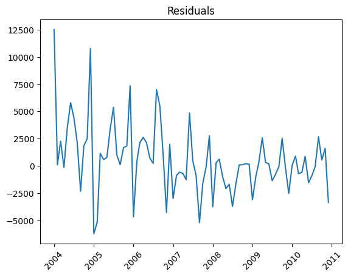

```
<statsmodels.tsa.statespace.mlemodel.PredictionResultsWrapper object at 0x7eba2623db40>
```

```python
# Fit ARIMA(1,0,1)x(0,1,1)[12] model to the data

#Best model for Baggage Complaints for United is ARIMA(1,0,1)x(0,1,1)[12]
fit_AR1 = ARIMA(bag_ts, order=(1,0,1), seasonal_order=(0, 1, 1, 12)).fit()


# Summary of the ARIMA model
print(fit_AR1.summary())

# Examine residuals from the model
residuals = fit_AR1.resid
plt.plot(residuals)
plt.title('Residuals')
plt.xticks(rotation=45)
plt.show()

#Generate the predicted values for the series
pred_units = fit_AR1.get_prediction()
print(pred_units)
```

- From Plot ACF and PACF for residuals, we can not see any significantly outstanding there.

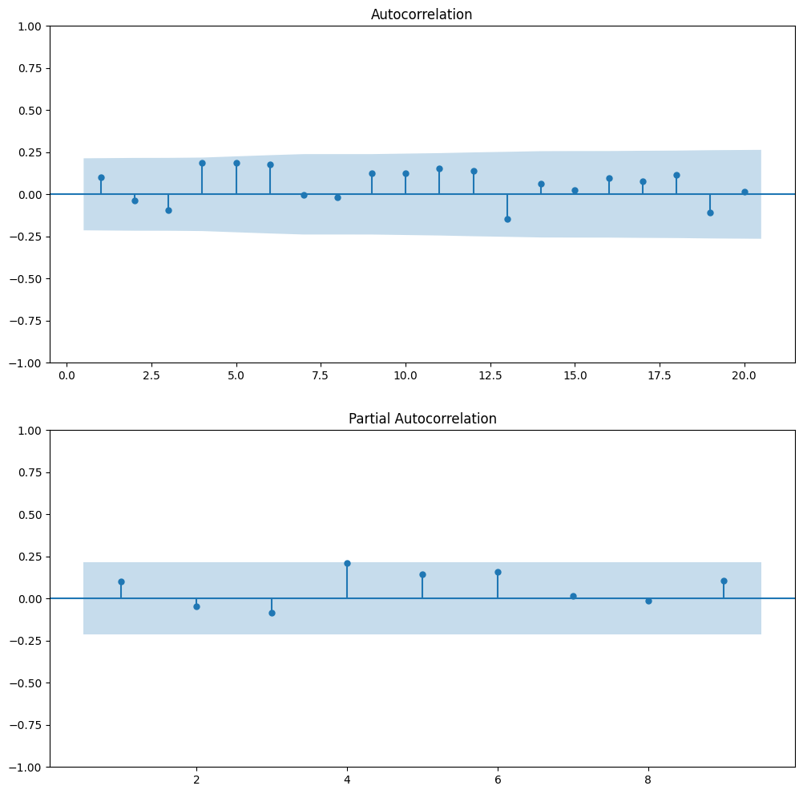

```python
# Plot ACF and PACF for residuals

fig, (ax1, ax2) = plt.subplots(2, 1, figsize=(12, 12))
plot_acf(residuals, ax=ax1, zero=False)
plot_pacf(residuals, ax=ax2, zero=False, lags=9)
plt.show()
```

After reviewing the ACF and PACF for the resiuals from this model and noticing that the Ljung Box test (below) indicates that the residuals are white noise, p-value = 0.1 >0.05, this seems to be a reasonable model for the data.

```python
#execute the Ljung Box test on the residuals

sm.stats.acorr_ljungbox(residuals, lags=[12], return_df=True)
```

|  | lb_stat | lb_pvalue |
| --- | --- | --- |
| 12 | 18.424866 | 0.103386 |

Convert predictions into a data frame in order to compute the forecast error

```python
# convert to data frame
predicted_mean = pred_units.predicted_mean
conf_int = pred_units.conf_int()

prediction_df = pd.DataFrame({
    'predicted_mean': predicted_mean,
    'lower_bound': conf_int.iloc[:, 0],
    'upper_bound': conf_int.iloc[:, 1]
})
prediction_df = prediction_df.tail(-1)
prediction_df.head()
```

| Date | predicted_mean | lower_bound | upper_bound |
| --- | --- | --- | --- |
| 2004-02-01 | 8877.523581 | 2308.238573 | 15446.808589 |
| 2004-03-01 | 8010.148141 | 1679.242038 | 14341.054243 |
| 2004-04-01 | 8220.446741 | 1916.472828 | 14524.420654 |
| 2004-05-01 | 7162.927350 | 859.526021 | 13466.328679 |
| 2004-06-01 | 7885.027953 | 1583.340640 | 14186.715265 |

Join actual values to predicted values

```python
# add back actuals --
prediction_df = pd.concat([prediction_df,bag_ts.to_frame(name='Baggage')],axis=1)
prediction_df = prediction_df.tail(-1)
prediction_df.head()
```

| Date | predicted_mean | lower_bound | upper_bound | Baggage |
| --- | --- | --- | --- | --- |
| 2004-02-01 | 8877.523581 | 2308.238573 | 15446.808589 | 8977 |
| 2004-03-01 | 8010.148141 | 1679.242038 | 14341.054243 | 10289 |
| 2004-04-01 | 8220.446741 | 1916.472828 | 14524.420654 | 8095 |
| 2004-05-01 | 7162.927350 | 859.526021 | 13466.328679 | 10618 |
| 2004-06-01 | 7885.027953 | 1583.340640 | 14186.715265 | 13684 |

Calculate the Forecast Error

```python
# calc error
errors = prediction_df['Baggage'] - prediction_df['predicted_mean']
# absolue value of error
errors_abs = errors.abs()
# -- mape --
mape = (errors_abs/prediction_df['Baggage'].abs()).mean()
# -- rmse
rmse = (errors**2).mean()**0.5
# -- print it out
print(f'MAPE = {mape:.3%}')
print(f'RMSE = {rmse:,.3f}')
```

```
MAPE = 14.014%
RMSE = 2,880.493
```

## Produce the forecast for the number of baggage claims expected for the first 6 months of 2011.

```python
# Generate forecast for the next six months
forecast = fit_AR1.get_forecast(steps=6)
mean_forecast = forecast.predicted_mean
confidence_intervals = forecast.conf_int()

# Create a DataFrame with forecasted values and confidence intervals
forecast_df = pd.DataFrame({
    'Forecasted_CPI': mean_forecast,
    'Lower_Bound': confidence_intervals.iloc[:, 0],
    'Upper_Bound': confidence_intervals.iloc[:, 1]
})

forecast_df
```

|  | Forecasted_CPI | Lower_Bound | Upper_Bound |
| --- | --- | --- | --- |
| 2011-01-01 | 10558.880550 | 6047.453083 | 15070.308016 |
| 2011-02-01 | 7716.470919 | 2537.663582 | 12895.278256 |
| 2011-03-01 | 9475.082087 | 3734.462212 | 15215.701962 |
| 2011-04-01 | 7834.568862 | 1607.491752 | 14061.645972 |
| 2011-05-01 | 8397.925840 | 1742.128457 | 15053.723223 |
| 2011-06-01 | 11098.022980 | 4059.863838 | 18136.182121 |

Plot the series and append the six month forecast. Notice that the forecast follows a pattern similar to the one observed in the actual data

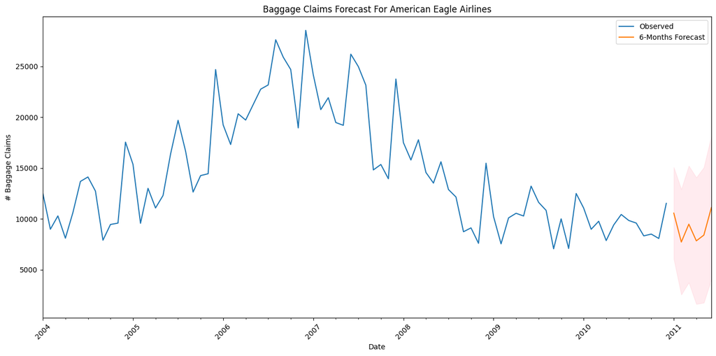

```python
# Plot forecast
plt.figure(figsize=(14, 7))
bag_ts.plot(label='Observed', legend=True)
mean_forecast.plot(label='6-Months Forecast', legend=True)
plt.fill_between(confidence_intervals.index,
                 confidence_intervals.iloc[:, 0],
                 confidence_intervals.iloc[:, 1], color='pink', alpha=0.3)
plt.title("Baggage Claims Forecast For American Eagle Airlines")
plt.xlabel("Date")
plt.ylabel("# Baggage Claims")
plt.xticks(rotation=45)
plt.tight_layout()
plt.legend()
plt.show()
```

# Canceled flights for American Eagle

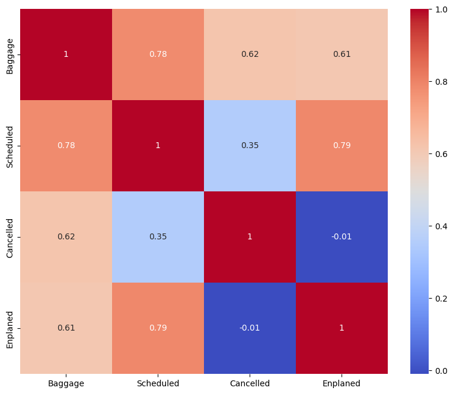

```python
bag_dat_sub = bag_dat.drop(columns=['Airline', 'Date', 'Month', 'Year'])


# Compute correlations
cormat = bag_dat_sub.corr()

# Round correlation matrix to 2 decimal places
cormat = cormat.round(2)

# Plot correlation matrix using a heatmap
plt.figure(figsize = (10,8))
sns.heatmap(cormat,annot=True, cmap = 'coolwarm')
plt.show()
```

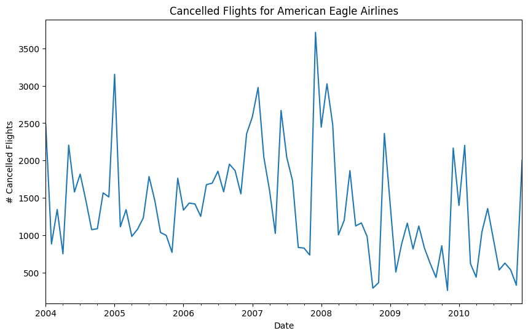

```python
# Convert date column to a date class variable

# Create a monthly index for the series
bag_dat['Date'] = pd.to_datetime(bag_dat['Date'], format="%b-%y")
bag_ts = pd.Series(bag_dat['Cancelled'].values, index=bag_dat['Date'])

bag_ts.index.freq = 'MS'


#Plot the series
plt.figure(figsize=(10, 6))
bag_ts.plot()
plt.title("Cancelled Flights for American Eagle Airlines")
plt.xlabel("Date")
plt.ylabel("# Cancelled Flights")
plt.show()
```

## Iteratively choose an ARIMA model for the number of cancelled flights for American Eagle

```python
#execute the Ljung Box test on the Cancelled series using 12 lags
Bags = bag_dat[['Cancelled']]

sm.stats.acorr_ljungbox(Bags, lags=[12], return_df=True)
```

|  | lb_stat | lb_pvalue |
| --- | --- | --- |
| 12 | 53.663831 | 3.137494e-07 |

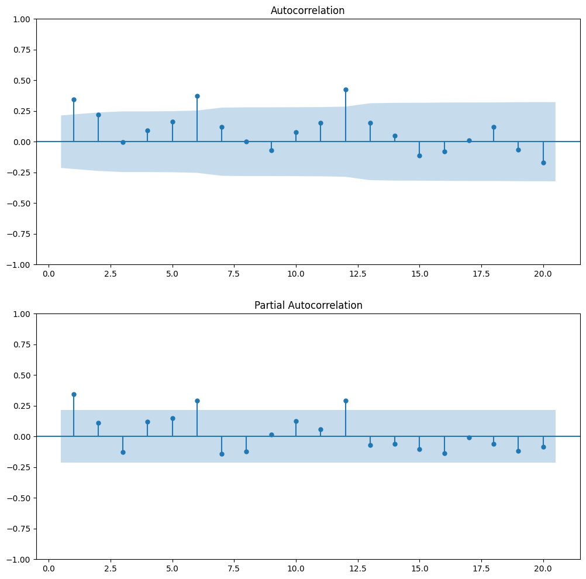

```python
#Plot the ACF and PACF for the Cancelled series

fig, (ax1, ax2) = plt.subplots(2, 1, figsize=(12, 12))
plot_acf(bag_ts, ax=ax1, zero=False)
plot_pacf(bag_ts, ax=ax2, zero=False)
plt.show()
```

For seasonal time series, the first step in the process is taking a seasonal difference. To do this, you need to include the seasonal_order(P,D,Q,s) option when you run the ARIMA procedure. P is the number of seasonal AR terms, Q is the number of seasonal MA terms, s is the length of the seasonal period (for example, s=12 if it takes 12 months to complete the seasonal cycle). To take a seasonal difference set D=1.

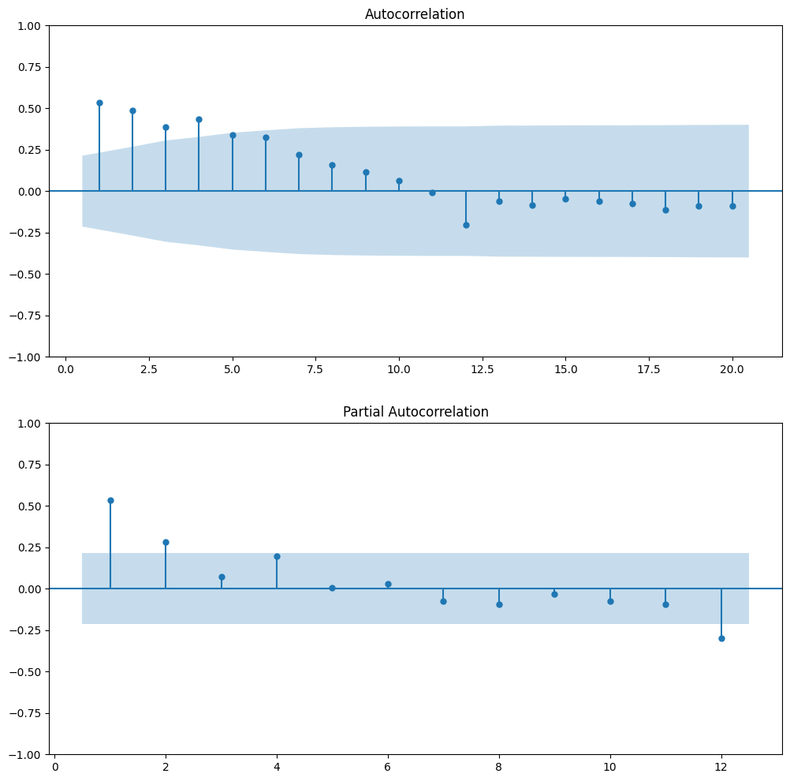

```python
# Fit ARIMA(0,0,0)x(0,1,0)[12] model to the data - This is simply taking the 12-month seasonal difference
#  which is yt - y(t-12)

fit_ARD12 = ARIMA(bag_ts, order=(0,0,0), seasonal_order=(0, 1, 0, 12)).fit()

# Plot ACF and PACF for residuals from the seasonal difference in order to
# assess the correlation still remaining in the data

residuals12 = fit_ARD12.resid

fig, (ax1, ax2) = plt.subplots(2, 1, figsize=(12, 12))
plot_acf(residuals12, ax=ax1, zero=False)
plot_pacf(residuals12, ax=ax2, zero=False, lags=12)
plt.show()
```

p-value >0.05, fail to reject Ho. Conclude series is not stationary and need a first difference

```python
#Dickey Fuller (single mean version)
adfuller(bag_ts, regression='c')
```

```
(-0.7916052271078315,
 0.8215755398680593,
 11,
 72,
 {'1%': -3.524624466842421,
  '5%': -2.9026070739026064,
  '10%': -2.5886785262345677},
 1124.7525079470279)
```

- Notice that the ACF and PACF for the residuals look like a typical autoregressive signature, so the next step might be to add p = 1 to include an AR(1) term in the model. This will not be sufficient to get the residuals to white noise. Recall that an MA term can help to smooth out a model after differencing. In this case we took a seasonal difference, so we'll include a seasonal MA term by setting Q=1 in the seasonal order.
- From the SARIMAX Results, we can see that the p-value of all the terms is less than 0.05, which means these terms are significant.

```
                                     SARIMAX Results
==========================================================================================
Dep. Variable:                                  y   No. Observations:                   84
Model:             ARIMA(1, 1, 0)x(0, 1, [1], 12)   Log Likelihood                -560.487
Date:                            Sun, 22 Oct 2023   AIC                           1126.974
Time:                                    23:27:02   BIC                           1133.762
Sample:                                01-01-2004   HQIC                          1129.674
                                     - 12-01-2010
Covariance Type:                              opg
==============================================================================
                 coef    std err          z      P>|z|      [0.025      0.975]
------------------------------------------------------------------------------
ar.L1         -0.5393      0.109     -4.948      0.000      -0.753      -0.326
ma.S.L12      -0.7067      0.143     -4.940      0.000      -0.987      -0.426
sigma2      3.896e+05   5.38e+04      7.247      0.000    2.84e+05    4.95e+05
===================================================================================
Ljung-Box (L1) (Q):                   0.91   Jarque-Bera (JB):                17.26
Prob(Q):                              0.34   Prob(JB):                         0.00
Heteroskedasticity (H):               1.31   Skew:                             0.75
Prob(H) (two-sided):                  0.51   Kurtosis:                         4.90
===================================================================================

Warnings:
[1] Covariance matrix calculated using the outer product of gradients (complex-step).
```

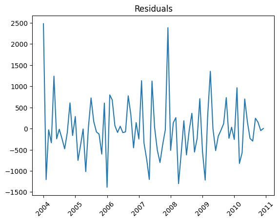

```
<statsmodels.tsa.statespace.mlemodel.PredictionResultsWrapper object at 0x7eb9e5d76230>
```

```python
# Fit ARIMA(1,1,0)x(0,1,1)[12] model to the data

#Best model for Baggage Complaints for United is ARIMA(1,0,0)x(0,1,1)[12]
fit_AR1 = ARIMA(bag_ts, order=(1,1,0), seasonal_order=(0, 1, 1, 12)).fit()


# Summary of the ARIMA model
print(fit_AR1.summary())

# Examine residuals from the model
residuals = fit_AR1.resid
plt.plot(residuals)
plt.title('Residuals')
plt.xticks(rotation=45)
plt.show()

#Generate the predicted values for the series
pred_units = fit_AR1.get_prediction()
print(pred_units)
```

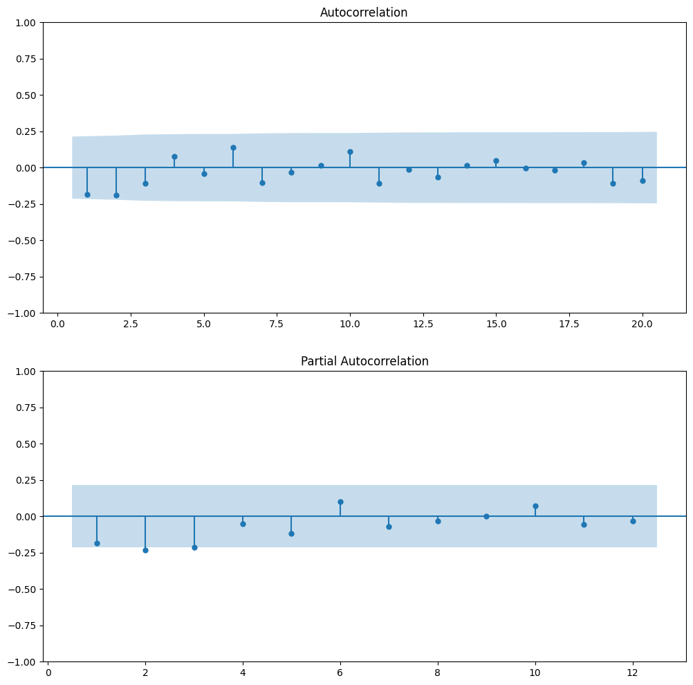

```python
# Plot ACF and PACF for residuals

fig, (ax1, ax2) = plt.subplots(2, 1, figsize=(12, 12))
plot_acf(residuals, ax=ax1, zero=False)
plot_pacf(residuals, ax=ax2, zero=False, lags=12)
plt.show()
```

After reviewing the ACF and PACF for the resiuals from this model and noticing that the Ljung Box test (below) indicates that the residuals are white noise,p-value = 0.36 >0.05 this seems to be a reasonable model for the data.

```python
#execute the Ljung Box test on the residuals, we want p value larger than 0.05

sm.stats.acorr_ljungbox(residuals, lags=[12], return_df=True)
```

|  | lb_stat | lb_pvalue |
| --- | --- | --- |
| 12 | 13.01792 | 0.36774 |

Convert predictions into a data frame in order to compute the forecast error

```python
# convert to data frame
predicted_mean = pred_units.predicted_mean
conf_int = pred_units.conf_int()

prediction_df = pd.DataFrame({
    'predicted_mean': predicted_mean,
    'lower_bound': conf_int.iloc[:, 0],
    'upper_bound': conf_int.iloc[:, 1]
})
prediction_df = prediction_df.tail(-1)
prediction_df.head()
```

| Date | predicted_mean | lower_bound | upper_bound |
| --- | --- | --- | --- |
| 2004-02-01 | 2091.101931 | -504.335055 | 4686.538917 |
| 2004-03-01 | 1374.901647 | -1187.364020 | 3937.167315 |
| 2004-04-01 | 1090.016233 | -1469.048991 | 3649.081457 |
| 2004-05-01 | 965.482564 | -1593.286102 | 3524.251231 |
| 2004-06-01 | 1820.229690 | -738.519144 | 4378.978525 |

Join actual values to predicted values

```python
# add back actuals --
prediction_df = pd.concat([prediction_df,bag_ts.to_frame(name='Cancelled')],axis=1)
prediction_df = prediction_df.tail(-1)
prediction_df.head()
```

| Date | predicted_mean | lower_bound | upper_bound | Cancelled |
| --- | --- | --- | --- | --- |
| 2004-02-01 | 2091.101931 | -504.335055 | 4686.538917 | 886 |
| 2004-03-01 | 1374.901647 | -1187.364020 | 3937.167315 | 1346 |
| 2004-04-01 | 1090.016233 | -1469.048991 | 3649.081457 | 755 |
| 2004-05-01 | 965.482564 | -1593.286102 | 3524.251231 | 2206 |
| 2004-06-01 | 1820.229690 | -738.519144 | 4378.978525 | 1580 |

Calculate the Forecast Error

```python
# calc error
errors = prediction_df['Cancelled'] - prediction_df['predicted_mean']
# absolue value of error
errors_abs = errors.abs()
# -- mape --
mape = (errors_abs/prediction_df['Cancelled'].abs()).mean()
# -- rmse
rmse = (errors**2).mean()**0.5
# -- print it out
print(f'MAPE = {mape:.3%}')
print(f'RMSE = {rmse:,.3f}')
```

```
MAPE = 41.615%
RMSE = 636.062
```

## Produce the forecast for the number of canceled flights for the first 6 months of 2011.

```python
# Generate forecast for the next six months
forecast = fit_AR1.get_forecast(steps=6)
mean_forecast = forecast.predicted_mean
confidence_intervals = forecast.conf_int()

# Create a DataFrame with forecasted values and confidence intervals
forecast_df = pd.DataFrame({
    'Forecasted_CPI': mean_forecast,
    'Lower_Bound': confidence_intervals.iloc[:, 0],
    'Upper_Bound': confidence_intervals.iloc[:, 1]
})

forecast_df
```

|  | Forecasted_CPI | Lower_Bound | Upper_Bound |
| --- | --- | --- | --- |
| 2011-01-01 | 1544.285559 | 317.452779 | 2771.118340 |
| 2011-02-01 | 1504.084563 | 153.544092 | 2854.625033 |
| 2011-03-01 | 956.224310 | -678.463101 | 2590.911721 |
| 2011-04-01 | 619.023610 | -1170.811512 | 2408.858732 |
| 2011-05-01 | 815.993164 | -1157.983579 | 2789.969906 |
| 2011-06-01 | 1238.974997 | -882.293256 | 3360.243250 |

Plot the series and append the six month forecast. Notice that the forecast follows a pattern similar to the one observed in the actual data

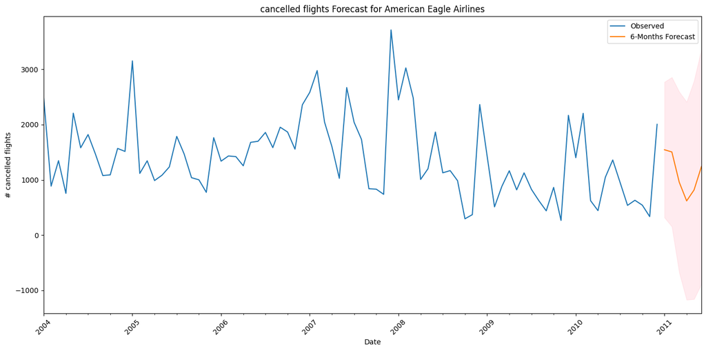

```python
# Plot forecast
plt.figure(figsize=(14, 7))
bag_ts.plot(label='Observed', legend=True)
mean_forecast.plot(label='6-Months Forecast', legend=True)
plt.fill_between(confidence_intervals.index,
                 confidence_intervals.iloc[:, 0],
                 confidence_intervals.iloc[:, 1], color='pink', alpha=0.3)
plt.title("cancelled flights Forecast for American Eagle Airlines")
plt.xlabel("Date")
plt.ylabel("# cancelled flights")
plt.xticks(rotation=45)
plt.tight_layout()
plt.legend()
plt.show()
```